# Running the EvoDemo-Hyper Matrix Population Model in R

Timothée Bonnet

2024-10-28

This code is associated with the manuscript “Toward a unified approach to modeling adaptation among demographers and evolutionary ecologists” submitted to Methods in Ecology and Evolution (MEE) by Joanie Van de Walle, Jimmy Garnier, Timothée Bonnet and Stephanie Jenouvrier.

# 1 Set-up

Packages that are needed to run the MPM function:

```r
library(pracma) # for data wrangling and plotting
library(gsignal) # for population growth rate
library(purrr) # for reformatting output
```

Packages to visualise results:

```r
library(tidyverse)
```

Load all MPM simulation functions:

```r
source("MPM_Functions.R")
```

# 2 Define species

We define 5 species as a collection of vital rates and life-history properties.

```r
species_info <- data.frame(species=1:5,
                           fecundity = c(10.9868, 4.9958, 0.9987 ,0.3004 , 0.2286),
                           fertility = c(10.9868/0.0965, 4.9958/0.25, 0.9987/0.385 ,0.3004/0.505 , 0.2286/0.8),
                           adult_survival = c(0.0365, 0.2, 0.8, 0.93, 0.95),
                           juvenile_survival = c(0.0965, 0.25, 0.385, 0.505, 0.8),
                           maturation_rate = c(0.9, 0.572, 0.4, 0.3, 0.07),
                           generation_time = c(2.0476, 2.3697, 6.2983, 15.8066, 23.7847))
```

# 3 Demonstration

## 3.1 An example

A single function is called to run the EvoDemo-Hyper Matrix Population Model (MPM).

We start by demonstrating the use of the function for species 1, using default parameters as used in the manuscript (this should take a few seconds):

```r
output1 <- MPM(h2 = 0.2, Vp=1, nind = 100, Beta = 0.15,
               Fe = species_info$fecundity[1],
               SA = species_info$adult_survival[1],
               SJ = species_info$juvenile_survival[1],
               S0 = species_info$juvenile_survival[1],
               Y = species_info$maturation_rate[1])
```

Note that we use the same survival probability, `species_info$juvenile_survival[1]`, for `SJ` (survival probability for juvenile individuals, who have not matured yet) and `S0` (survival probability on the birth year). It is possible to use different probabilities for those two rates, as was done in the appendix of the manuscript.

The output contains lots of information.

```r
str(output1)
```

```
## List of 7
##  $ T_GEN                    : num [1, 1] 2.05
##  $ V_ADAPT                  : num 0.0147
##  $ LAMBDA0                  : num 1
##  $ V                        : num 0.0146
##  $ properties_per_year      :'data.frame':   102 obs. of  16 variables:
##   ..$ year   : int [1:102] 1 2 3 4 5 6 7 8 9 10 ...
##   ..$ Fe     : num [1:102] 11.1 11.2 11.2 11.2 11.2 ...
##   ..$ f      : num [1:102] 115 116 116 116 116 ...
##   ..$ SA     : num [1:102] 0.0365 0.0365 0.0365 0.0365 0.0365 0.0365 0.0365 0.0365 0.0365 0.0365 ...
##   ..$ SJ     : num [1:102] 0.0965 0.0965 0.0965 0.0965 0.0965 0.0965 0.0965 0.0965 0.0965 0.0965 ...
##   ..$ Y      : num [1:102] 0.9 0.9 0.9 0.9 0.9 0.9 0.9 0.9 0.9 0.9 ...
##   ..$ Z      : num [1:102] -2.17e-16 2.72e-02 2.98e-02 5.60e-02 5.96e-02 ...
##   ..$ Va     : num [1:102] 0.2 0.2 0.2 0.2 0.2 ...
##   ..$ Vp     : num [1:102] 0.999 0.999 0.999 0.999 0.999 ...
##   ..$ M_EBVSA: num [1:102] -1.77e-16 -1.50e-16 2.86e-02 2.99e-02 5.73e-02 ...
##   ..$ M_EBVSJ: num [1:102] -1.59e-16 2.97e-02 3.00e-02 5.83e-02 5.99e-02 ...
##   ..$ M_EBVS : num [1:102] -1.74e-16 2.73e-02 2.99e-02 5.60e-02 5.97e-02 ...
##   ..$ T_GEN  : num [1:102] 2.07 2.08 2.08 2.09 2.09 ...
##   ..$ lambda : num [1:102] 1.01 1.01 1.01 1.01 1.01 ...
##   ..$ age_juv: num [1:102] 0.918 0.918 0.918 0.918 0.918 ...
##   ..$ N      : num [1:102] 100 101 101 103 103 ...
##  $ pheno_distribution       : tibble [2,040 × 4] (S3: tbl_df/tbl/data.frame)
##   ..$ phenotypic_class   : int [1:2040] 1 1 1 1 1 1 1 1 1 1 ...
##   ..$ phenotypic_midvalue: num [1:2040] -3.8 -3.8 -3.8 -3.8 -3.8 -3.8 -3.8 -3.8 -3.8 -3.8 ...
##   ..$ year               : int [1:2040] 1 2 3 4 5 6 7 8 9 10 ...
##   ..$ density            : num [1:2040] 0.01168 0.01064 0.01054 0.00967 0.00955 ...
##  $ midpoint_phenotypic_class: num [1:20] -3.8 -3.4 -3 -2.6 -2.2 -1.8 -1.4 -1 -0.6 -0.2 ...
```

To start with, we can visualise population size:

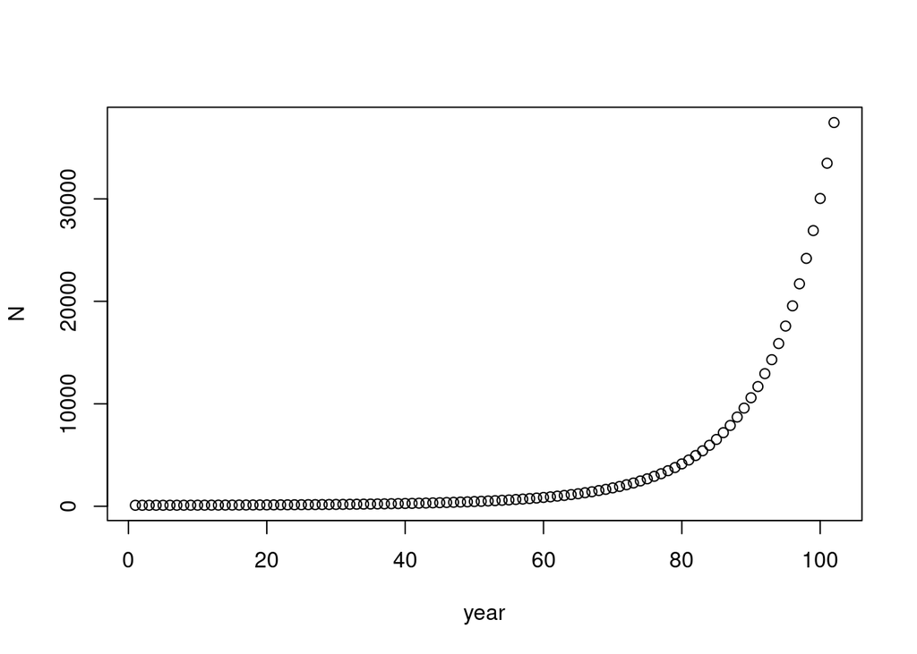

```r
plot(output1$properties_per_year[,c("year", "N")])
```

We can extract the distribution of phenotypes through time in `$pheno_distribution`:

```r
pheno_distribution <- output1$pheno_distribution
```

We can visualise the number of individuals expected in each phenotypic class through 100 years of simulation:

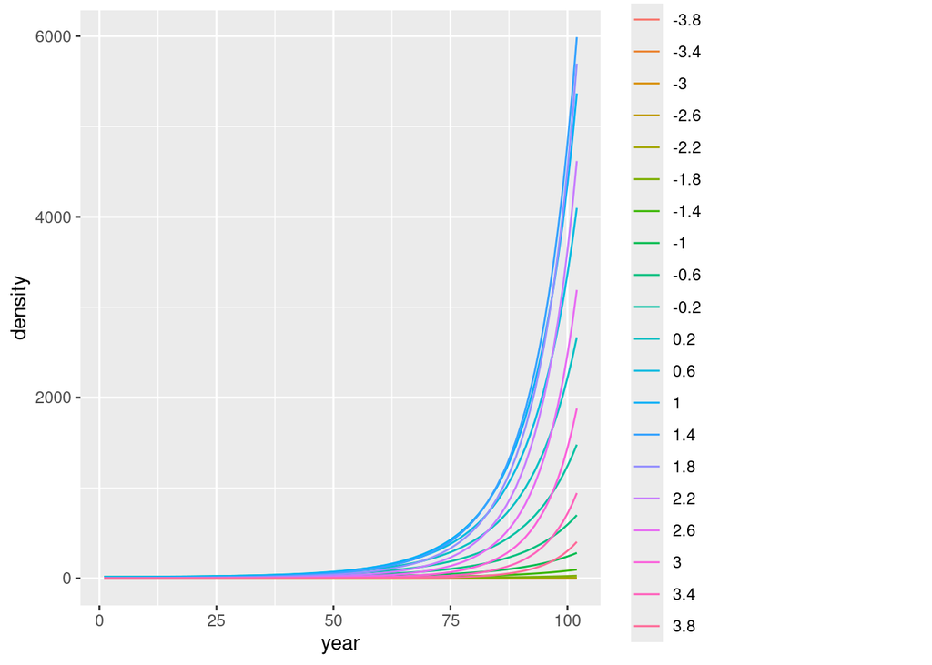

```r
pheno_distribution %>% ggplot(aes(x=year, y=density, colour=as.factor(phenotypic_midvalue))) + geom_line()
```

The distribution of phenotypes every 20 years:

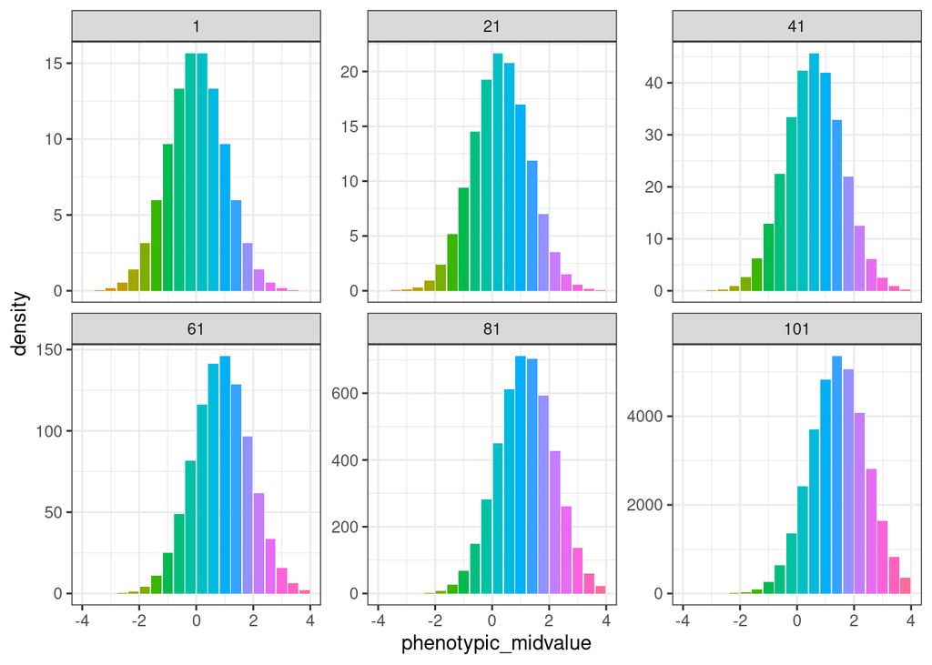

```r
pheno_distribution %>%  dplyr::filter(year %in% seq( from=1, to =101, by=20)) %>%
  ggplot(aes(x=phenotypic_midvalue, y=density, fill=as.factor(phenotypic_midvalue))) +
  geom_col() +
  facet_wrap(~year, scales = "free_y") +
  theme_bw() +
  theme(legend.position = "none")
```

The mean breeding values among adults and juveniles through time:

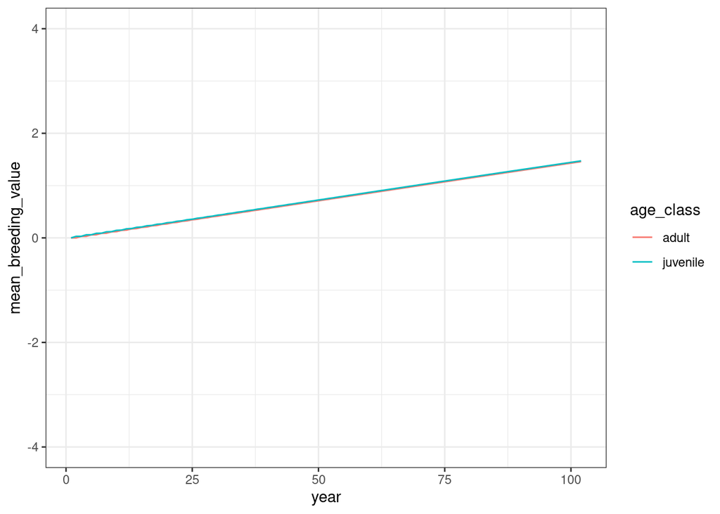

```r
BV <- output1$properties_per_year[,c("year", "M_EBVSA", "M_EBVSJ")]
colnames(BV) <- c("year", "adult", "juvenile")
BV <- BV %>% pivot_longer(cols=2:3, values_to = "mean_breeding_value", names_to = "age_class")

ggplot(BV, aes(x=year, y=mean_breeding_value, color=age_class)) +
  ylim(c(-4, +4)) +
  geom_line() + theme_bw()
```

## 3.2 Options

### 3.2.1 Phenotypic classes

We can change the number of phenotypic and breeding value classes considered (`g=`). The default here was 20, which takes about 2 seconds on this machine. With only 10 classes the algorithm takes about 1 second:

```r
output2 <- MPM(g = 10,
               Fe = species_info$fecundity[1],
               SA = species_info$adult_survival[1],
               SJ = species_info$juvenile_survival[1],
               S0 = species_info$juvenile_survival[1],
               Y = species_info$maturation_rate[1])
```

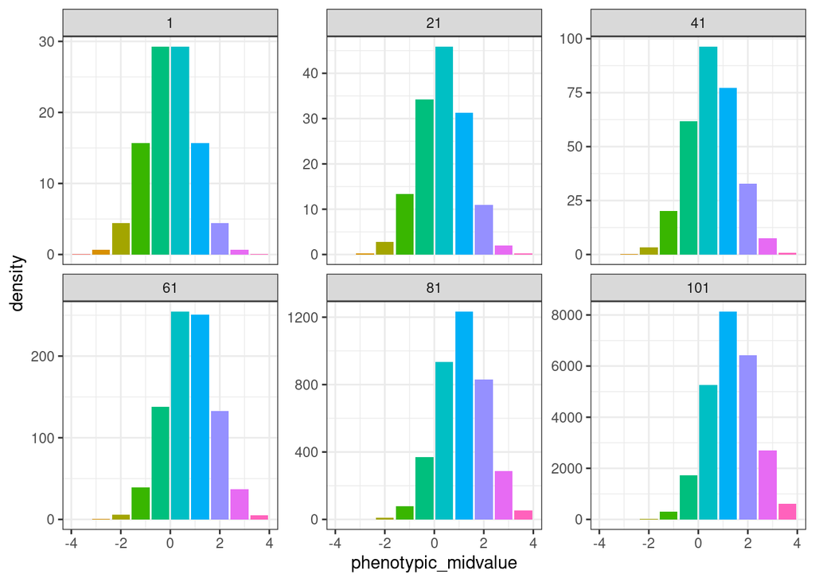

```r
output2$pheno_distribution %>%
   dplyr::filter(year %in% seq( from=1, to =101, by=20)) %>%
  ggplot(aes(x=phenotypic_midvalue, y=density, fill=as.factor(phenotypic_midvalue))) +
  geom_col() +
  facet_wrap(~year, scales = "free_y", labeller = ) +
  theme_bw() +
  theme(legend.position = "none")
```

And about 8 seconds for 40 classes:

```r
output2b <- MPM(g = 40,
               Fe = species_info$fecundity[1],
               SA = species_info$adult_survival[1],
               SJ = species_info$juvenile_survival[1],
               S0 = species_info$juvenile_survival[1],
               Y = species_info$maturation_rate[1])
```

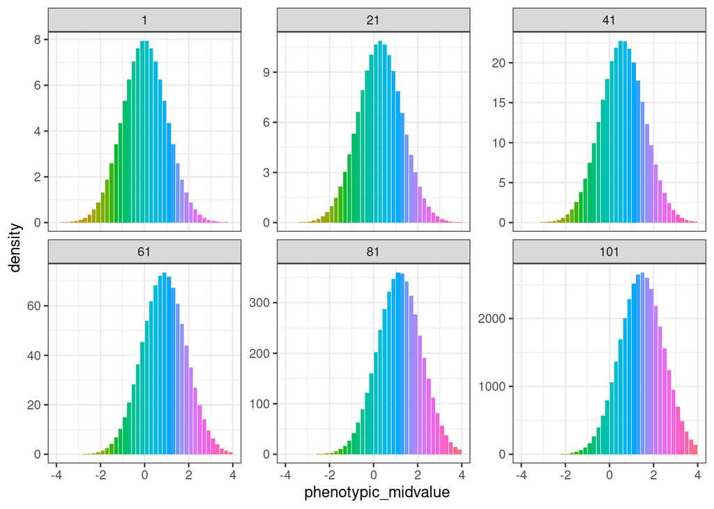

```r
output2b$pheno_distribution %>%
   dplyr::filter(year %in% seq( from=1, to =101, by=20)) %>%
  ggplot(aes(x=phenotypic_midvalue, y=density, fill=as.factor(phenotypic_midvalue))) +
  geom_col() +
  facet_wrap(~year, scales = "free_y", labeller = ) +
  theme_bw() +
  theme(legend.position = "none")
```

The initial phenotype has a mean of zero. We set the range of phenotypes considered around that value with the parameter `xp=`. The default is 4. We can increase it to 8 so give more space for the trait to evolve:

```r
output3 <- MPM(g = 20,
               xp = 8,
               Fe = species_info$fecundity[1],
               SA = species_info$adult_survival[1],
               SJ = species_info$juvenile_survival[1],
               S0 = species_info$juvenile_survival[1],
               Y = species_info$maturation_rate[1])
```

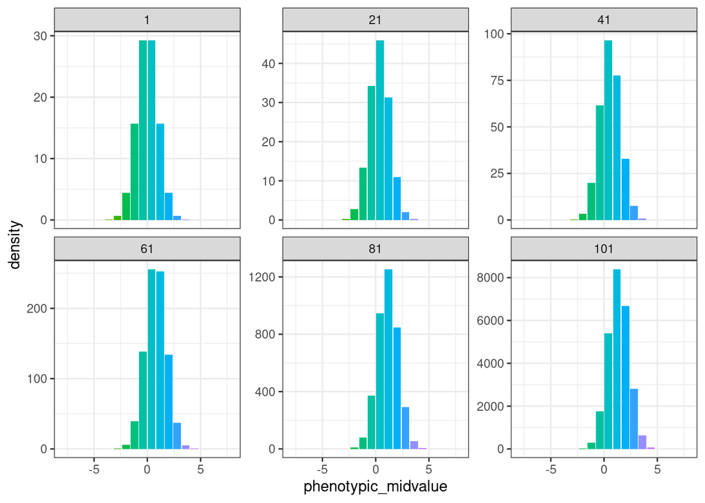

```r
output3$pheno_distribution %>%
   dplyr::filter(year %in% seq( from=1, to =101, by=20)) %>%
  ggplot(aes(x=phenotypic_midvalue, y=density, fill=as.factor(phenotypic_midvalue))) +
  geom_col() +
  facet_wrap(~year, scales = "free_y", labeller = ) +
  theme_bw() +
  theme(legend.position = "none")
```

Given the broader range there was not enough time to see much change. We can increase the number of timesteps from 100 to 500:

```r
output4 <- MPM(g = 20,
               xp = 8,
               timeA = 500,
               Fe = species_info$fecundity[1],
               SA = species_info$adult_survival[1],
               SJ = species_info$juvenile_survival[1],
               S0 = species_info$juvenile_survival[1],
               Y = species_info$maturation_rate[1])
```

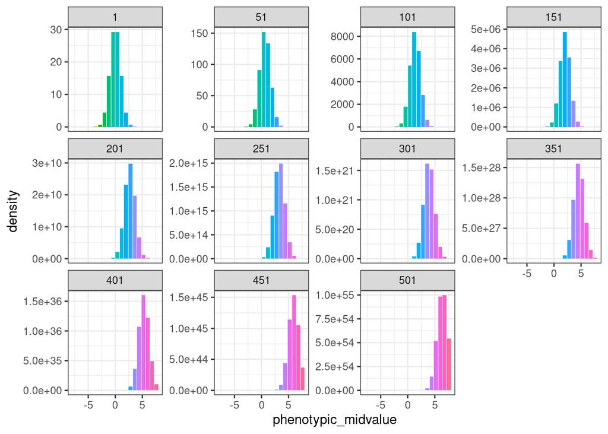

```r
output4$pheno_distribution %>%
   dplyr::filter(year %in% seq( from=1, to =501, by=50)) %>%
  ggplot(aes(x=phenotypic_midvalue, y=density, fill=as.factor(phenotypic_midvalue))) +
  geom_col() +
  facet_wrap(~year, scales = "free_y", labeller = ) +
  theme_bw() +
  theme(legend.position = "none")
```

Eventually the phenotypic distribution hits the boundary of the highest possible phenotype, which makes the simulation unreliable from that point in time (around year 350 here). Also, note the absurd exponential population growth, evidenced by the y-axis. This is expected as the model consider only directional selection and does not contain density dependence.

By default, the option `stabilise_population_structure` is set to `TRUE`, which means that the simulation starts with a stable stage structure. If you decide to set the parameter to `FALSE` you may observe transient oscillating dynamics:

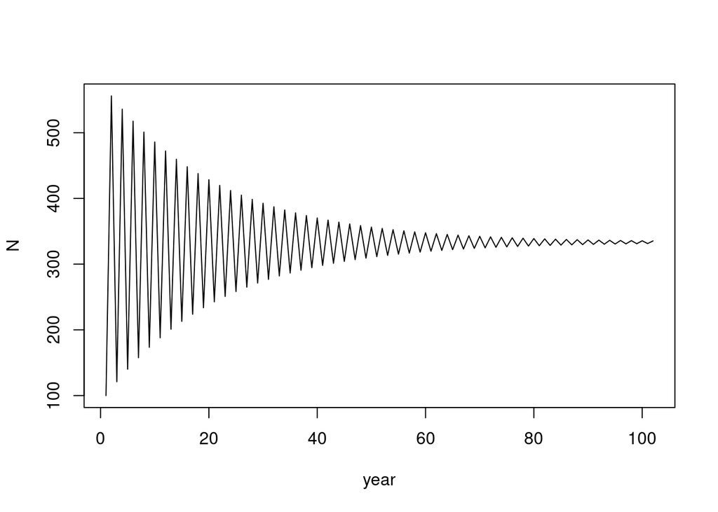

```r
output5 <- MPM(Beta = 0, Fe = 10.9868, SA = 0.0365, SJ=0.0965, S0=0.0965, Y=0.9, g=10, stabilise_population_structure = FALSE)
plot(output5$properties_per_year[,c("year","N")], type="l")
```

By default, the vital rates given as option values are used as is, which may correspond to a population that is initially growing or shrinking:

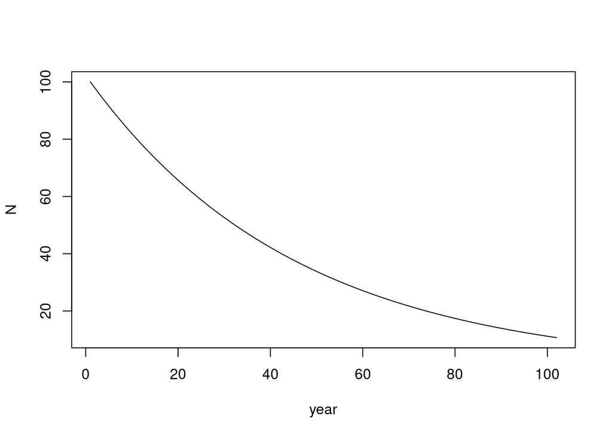

```r
output6 <- MPM(Beta = 0, Fe = 10.5, SA = 0.0365, SJ=0.0965, S0=0.0965, Y=0.9, g=10)
plot(output6$properties_per_year[,c("year","N")], type="l")
```

The option `enforce_initial_lambda1`, if set to `TRUE`, will adjust `Fe` so that the initial asymptotic growth rate is exactly 1. A message will show the adjusted value of `Fe`:

```r
output6b <- MPM(Beta = 0, Fe = 10.5, SA = 0.0365, SJ=0.0965, S0=0.0965, Y=0.9, g=10, enforce_initial_lambda1 = TRUE)
```

```
## I have adjusted Fe to 10.986784398388 because the enforce_initial_lambda1 is set to TRUE.
```

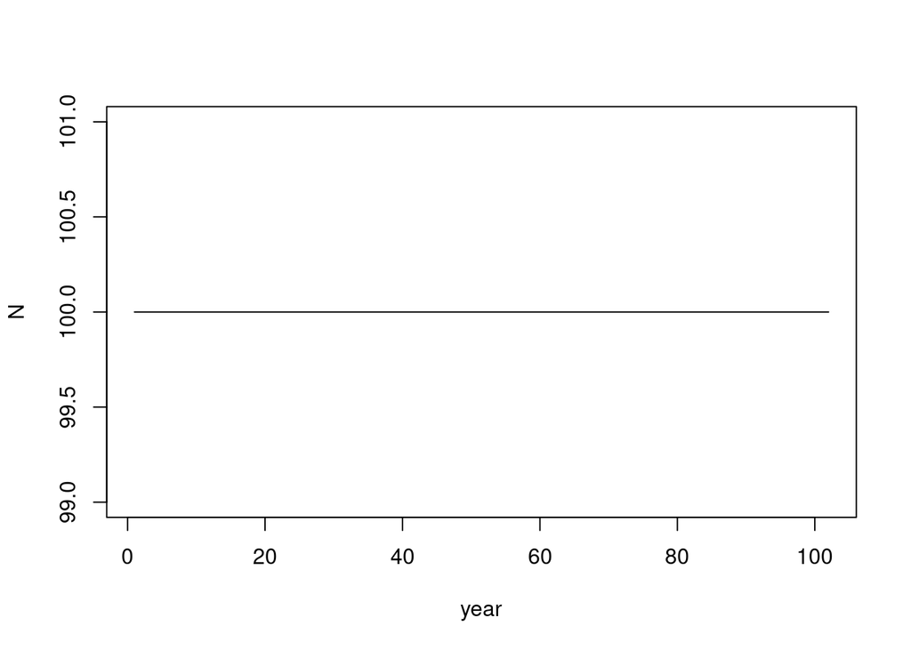

```r
plot(output6b$properties_per_year[,c("year","N")], type="l")
```

### 3.2.2 Heritability and selection

We can check that without selection there is no phenotypic or genetic change:

```r
output_nobeta <- MPM(g = 20,
               xp = 4,
               timeA = 100,
               h2 = 0.2,
               Beta = 0,
               nind = 100,
               Fe = species_info$fecundity[4],
               SA = species_info$adult_survival[4],
               SJ = species_info$juvenile_survival[4],
               S0 = species_info$juvenile_survival[4],
               Y = species_info$maturation_rate[4], enforce_initial_lambda1 = TRUE)
```

```
## I have adjusted Fe to 0.298712871287129 because the enforce_initial_lambda1 is set to TRUE.
```

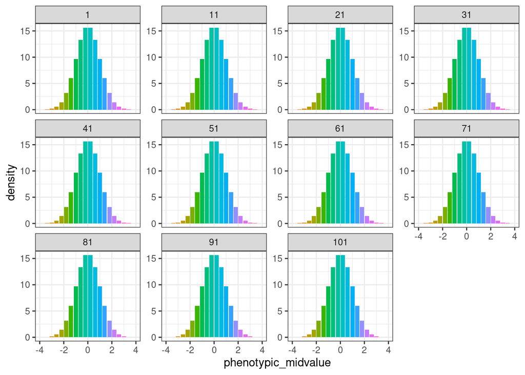

```r
output_nobeta$pheno_distribution %>%
   dplyr::filter(year %in% seq( from=1, to =101, by=10)) %>%
  ggplot(aes(x=phenotypic_midvalue, y=density, fill=as.factor(phenotypic_midvalue))) +
  geom_col() +
  facet_wrap(~year, scales = "free_y", labeller = ) +
  theme_bw() +
  theme(legend.position = "none")
```

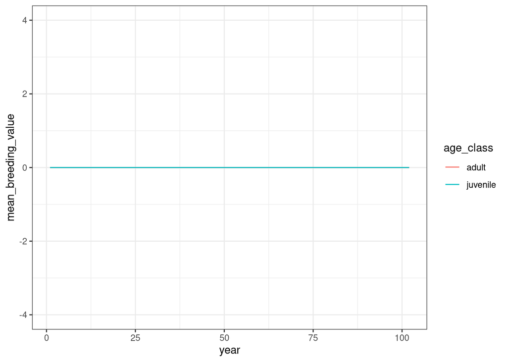

```r
BV <- output_nobeta$properties_per_year[,c("year", "M_EBVSA", "M_EBVSJ")]
colnames(BV) <- c("year", "adult", "juvenile")
BV <- BV %>% pivot_longer(cols=2:3, values_to = "mean_breeding_value", names_to = "age_class")

ggplot(BV, aes(x=year, y=mean_breeding_value, color=age_class)) +
  ylim(c(-4, +4)) +
  geom_line() + theme_bw()
```

Population size is constant

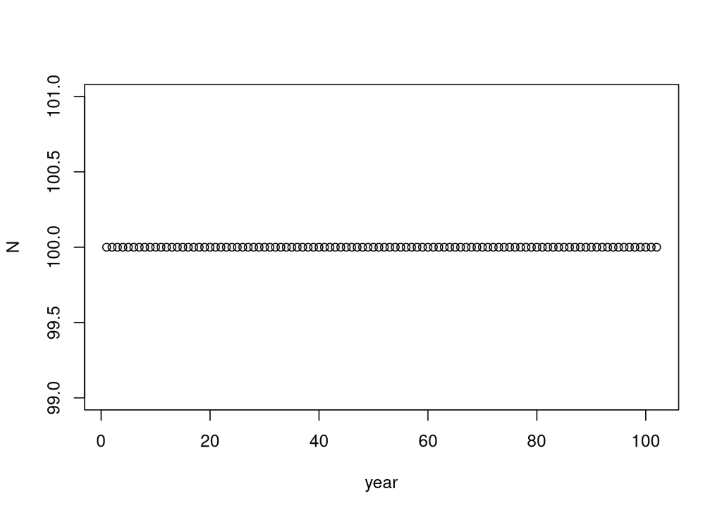

```r
plot(output_nobeta$properties_per_year[,c("year", "N")])
```

As is the asymptotic population growth rate

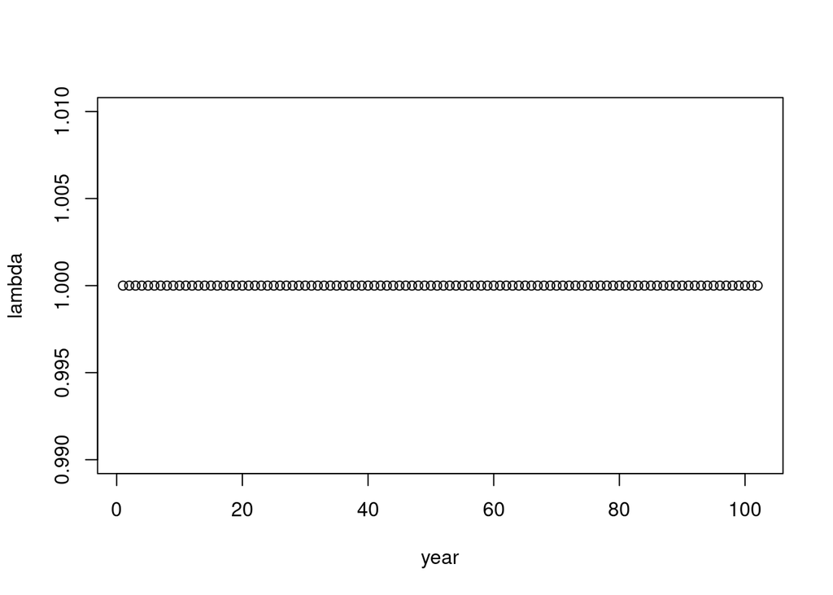

```r
plot(output_nobeta$properties_per_year[,c("year", "lambda")])
```

When there is selection but a low heritability (we set the heritability to 0.01 as it cannot be exactly 0 or 1; and as the realised heritability is constrained by the number of classes `g` and the phenotypic range `xp` considered):

```r
output_smallh2 <- MPM(g = 20,
               xp = 2,
               timeA = 100,
               h2 = 0.01,
               Beta = 0.15,
               nind = 100,
               Fe = species_info$fecundity[4],
               SA = species_info$adult_survival[4],
               SJ = species_info$juvenile_survival[4],
               S0 = species_info$juvenile_survival[4],
               Y = species_info$maturation_rate[4],
               enforce_initial_lambda1 = TRUE)
```

```
## Warning in MPM(g = 20, xp = 2, timeA = 100, h2 = 0.01, Beta = 0.15, nind = 100,
## : g is probably too low given h2 and xp. There are not enough breeding value
## classes to house Va below (xp/g)^2. Check estimates of Va and Vp in the output
## to see the realised h2. You may increase xp or decrease g.
```

```
## I have adjusted Fe to 0.298712871287129 because the enforce_initial_lambda1 is set to TRUE.
```

We get a warning message. The dynamic is not necessarily wrong, but maybe not exactly what you expected:

population size increases a bit:

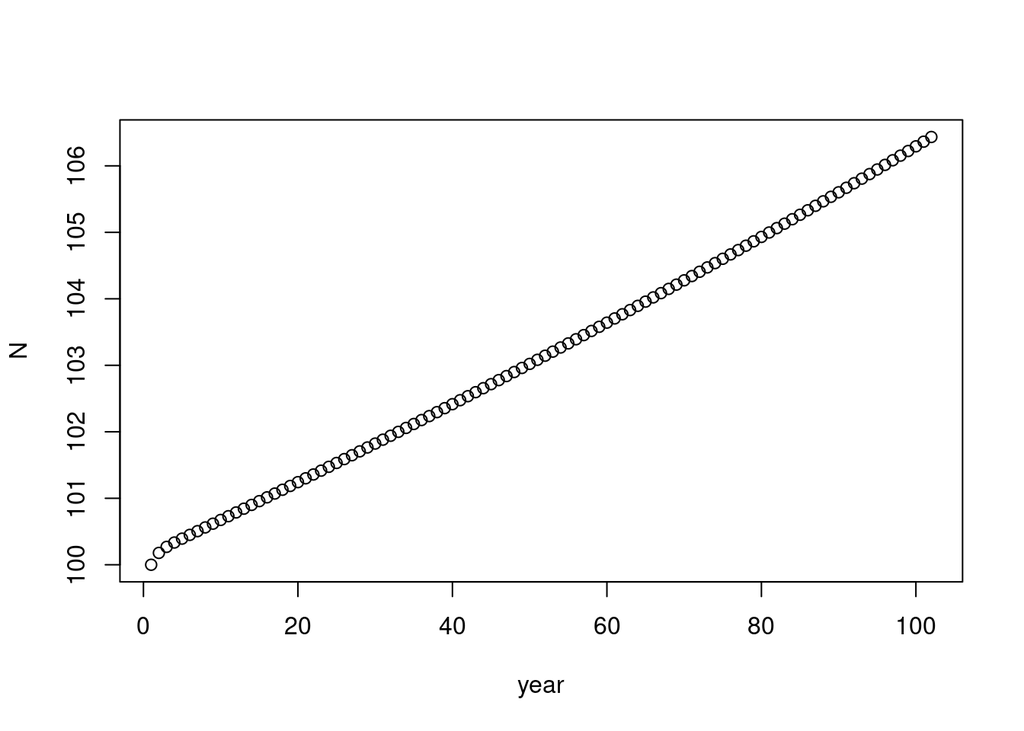

```r
plot(output_smallh2$properties_per_year[,c("year", "N")])
```

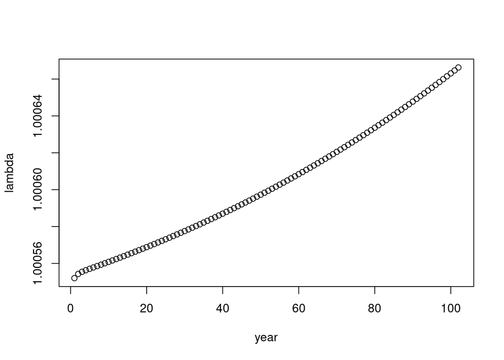

```r
plot(output_smallh2$properties_per_year[,c("year", "lambda")])
```

What we see is a little bit of adaptation, eroding away the additive genetic variance:

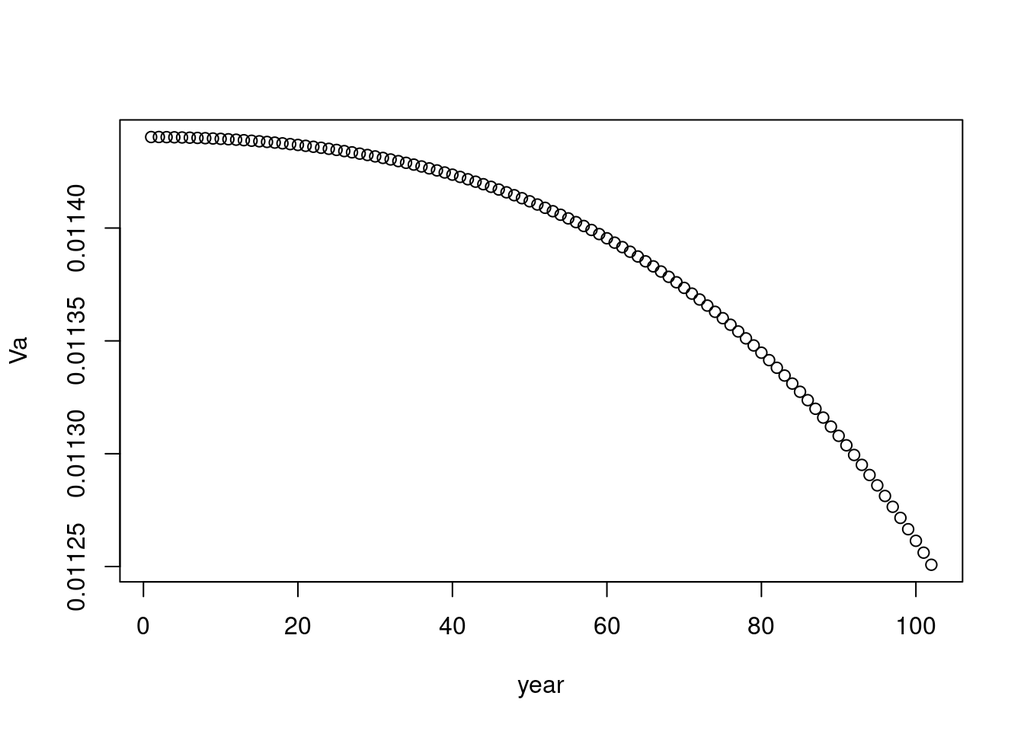

```r
plot(output_smallh2$properties_per_year[,c("year", "Va")])
```

This erosion may be seen as realistic, but is also an artefact of the algorithm. We do not model genes explicitly, so we do not have a clear prediction of what should happen to Va. Also, note that the value of Va starts a bit above the 0.01 asked for. This is an artefact of the breeding value distribution being too narrow compared to the coarsness of the phenotypic classes. The realised initial Va cannot go below `((xp/g)^2)` and will tend to erode from values around that and below.

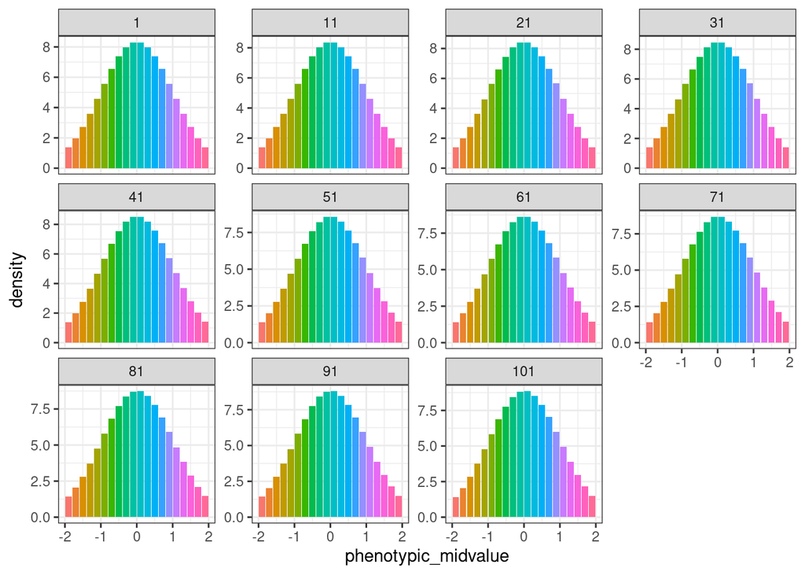

```r
output_smallh2$pheno_distribution %>%
   dplyr::filter(year %in% seq( from=1, to =101, by=10)) %>%
  ggplot(aes(x=phenotypic_midvalue, y=density, fill=as.factor(phenotypic_midvalue))) +
  geom_col() +
  facet_wrap(~year, scales = "free_y") +
  theme_bw() +
  theme(legend.position = "none")
```